# Explore_bikeshare_data

### Explore Bike Share Data

For this project, your goal is to ask and answer three questions about the available bikeshare data from Washington, Chicago, and New York. This notebook can be submitted directly through the workspace when you are confident in your results.

You will be graded against the project [Rubric](https://review.udacity.com/#!/rubrics/2508/view) by a mentor after you have submitted. To get you started, you can use the template below, but feel free to be creative in your solutions!

```r
ny = read.csv('new_york_city.csv')
wash = read.csv('washington.csv')
chi = read.csv('chicago.csv')
```

```r
head(ny)
```

| X | Start.Time | End.Time | Trip.Duration | Start.Station | End.Station | User.Type | Gender | Birth.Year |
| --- | --- | --- | --- | --- | --- | --- | --- | --- |
| 5688089 | 2017-06-11 14:55:05 | 2017-06-11 15:08:21 | 795 | Suffolk St & Stanton St | W Broadway & Spring St | Subscriber | Male | 1998 |
| 4096714 | 2017-05-11 15:30:11 | 2017-05-11 15:41:43 | 692 | Lexington Ave & E 63 St | 1 Ave & E 78 St | Subscriber | Male | 1981 |
| 2173887 | 2017-03-29 13:26:26 | 2017-03-29 13:48:31 | 1325 | 1 Pl & Clinton St | Henry St & Degraw St | Subscriber | Male | 1987 |
| 3945638 | 2017-05-08 19:47:18 | 2017-05-08 19:59:01 | 703 | Barrow St & Hudson St | W 20 St & 8 Ave | Subscriber | Female | 1986 |
| 6208972 | 2017-06-21 07:49:16 | 2017-06-21 07:54:46 | 329 | 1 Ave & E 44 St | E 53 St & 3 Ave | Subscriber | Male | 1992 |
| 1285652 | 2017-02-22 18:55:24 | 2017-02-22 19:12:03 | 998 | State St & Smith St | Bond St & Fulton St | Subscriber | Male | 1986 |

```r
head(wash)
```

| X | Start.Time | End.Time | Trip.Duration | Start.Station | End.Station | User.Type |
| --- | --- | --- | --- | --- | --- | --- |
| 1621326 | 2017-06-21 08:36:34 | 2017-06-21 08:44:43 | 489.066 | 14th & Belmont St NW | 15th & K St NW | Subscriber |
| 482740 | 2017-03-11 10:40:00 | 2017-03-11 10:46:00 | 402.549 | Yuma St & Tenley Circle NW | Connecticut Ave & Yuma St NW | Subscriber |
| 1330037 | 2017-05-30 01:02:59 | 2017-05-30 01:13:37 | 637.251 | 17th St & Massachusetts Ave NW | 5th & K St NW | Subscriber |
| 665458 | 2017-04-02 07:48:35 | 2017-04-02 08:19:03 | 1827.341 | Constitution Ave & 2nd St NW/DOL | M St & Pennsylvania Ave NW | Customer |
| 1481135 | 2017-06-10 08:36:28 | 2017-06-10 09:02:17 | 1549.427 | Henry Bacon Dr & Lincoln Memorial Circle NW | Maine Ave & 7th St SW | Subscriber |
| 1148202 | 2017-05-14 07:18:18 | 2017-05-14 07:24:56 | 398.000 | 1st & K St SE | Eastern Market Metro / Pennsylvania Ave & 7th St SE | Subscriber |

```r
head(chi)
```

| X | Start.Time | End.Time | Trip.Duration | Start.Station | End.Station | User.Type | Gender | Birth.Year |
| --- | --- | --- | --- | --- | --- | --- | --- | --- |
| 1423854 | 2017-06-23 15:09:32 | 2017-06-23 15:14:53 | 321 | Wood St & Hubbard St | Damen Ave & Chicago Ave | Subscriber | Male | 1992 |
| 955915 | 2017-05-25 18:19:03 | 2017-05-25 18:45:53 | 1610 | Theater on the Lake | Sheffield Ave & Waveland Ave | Subscriber | Female | 1992 |
| 9031 | 2017-01-04 08:27:49 | 2017-01-04 08:34:45 | 416 | May St & Taylor St | Wood St & Taylor St | Subscriber | Male | 1981 |
| 304487 | 2017-03-06 13:49:38 | 2017-03-06 13:55:28 | 350 | Christiana Ave & Lawrence Ave | St. Louis Ave & Balmoral Ave | Subscriber | Male | 1986 |
| 45207 | 2017-01-17 14:53:07 | 2017-01-17 15:02:01 | 534 | Clark St & Randolph St | Desplaines St & Jackson Blvd | Subscriber | Male | 1975 |
| 1473887 | 2017-06-26 09:01:20 | 2017-06-26 09:11:06 | 586 | Clinton St & Washington Blvd | Canal St & Taylor St | Subscriber | Male | 1990 |

### Question 1

Which month has the highest rentals?

```r
library(plyr)
library(dplyr)
library(ggplot2)
library(scales)

#Introducing Month function:
month <- function(data) { start_date  <-  sapply(strsplit(as.character(data$Start.Time), " "), "[", 1)


month <- substr(x = start_date, 6, 7) }
month_chi <- month(chi)
chi['month'] <- month_chi
month_chi <- month(chi)
chi['month'] <- month_chi
month_wash <- month(wash)
wash['month'] <- month_wash

##call function for ny
month_ny <- month(ny)
ny['month'] <- month_ny
final = (ny$month)

##call function wash
month_wash <- month(wash)
wash['month'] <- month_wash
final = (wash$month)

##call function for chi
month_chi <- month(chi)
chi['month'] <- month_chi
final =(chi$month)
```

```
   01    02    03    04    05    06
 8946 11563 12612 18522 17072 20335
```

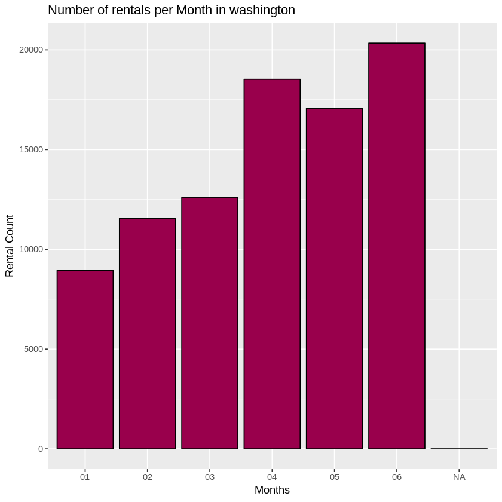

```r
#For Washington:
   ggplot(aes(x = month), data = wash) +
   geom_bar(color = 'black', fill = '#99004C') +
   xlab('Months') +
   ylab('Rental Count')+
   ggtitle("Number of rentals per Month in washington")

#Numeric confirmation:
table(wash$month)
```

```
  01   02   03   04   05   06
 650  930  803 1526 1905 2816
```

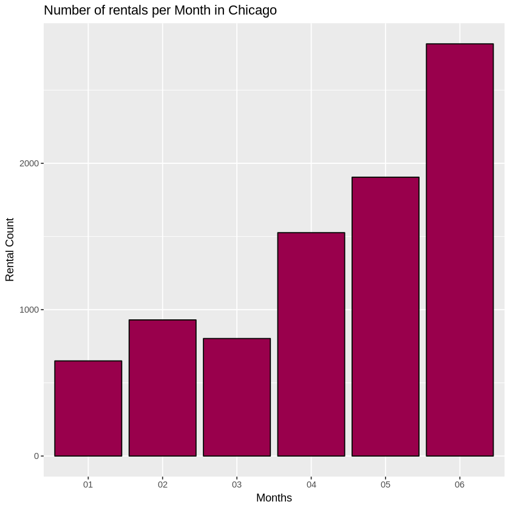

```r
#For Chicago:
   ggplot(aes(x = month), data = chi) +
   geom_bar(color = 'black', fill = '#99004C') +
   xlab('Months') +
   ylab('Rental Count')+
   ggtitle("Number of rentals per Month in Chicago")

#Numeric confirmation:
   table(chi$month)
```

```
   01    02    03    04    05    06
 5745  6364  5820 10661 12180 14000
```

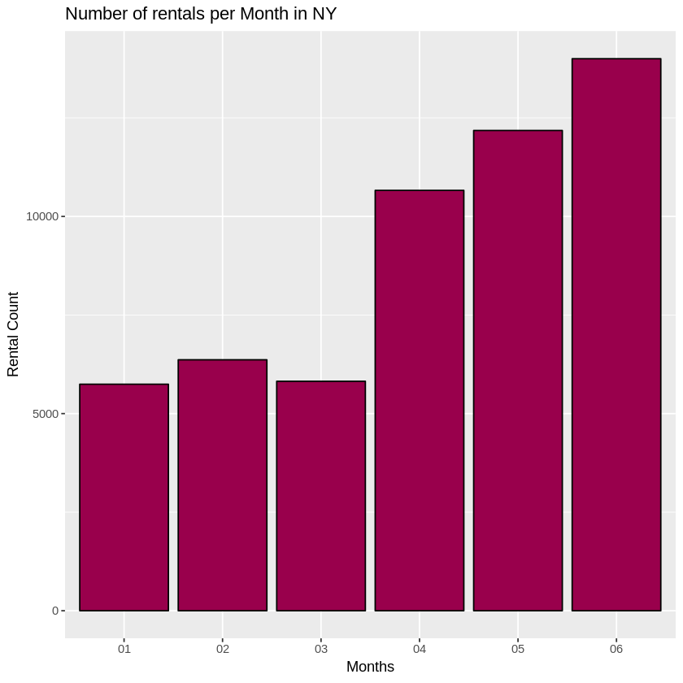

```r
#For Ny:
   ggplot(aes(x = month), data = ny) +
         geom_bar(color = 'black', fill = '#99004C') +
         xlab('Months') +
         ylab('Rental Count')+
         ggtitle("Number of rentals per Month in NY")

#Numeric confirmation:
   table(ny$month)
```

# Answer: All three cities exprience the highest numbers of rental in month 06.

### Question 2

What are the counts of each user type?

```
             Customer Subscriber
       119       5558      49093
```

```
ny$month: 01
             Customer Subscriber
        29        183       5533
------------------------------------------------------------
ny$month: 02
             Customer Subscriber
        53        338       5973
------------------------------------------------------------
ny$month: 03
             Customer Subscriber
        36        226       5558
------------------------------------------------------------
ny$month: 04
             Customer Subscriber
         0       1543       9118
------------------------------------------------------------
ny$month: 05
             Customer Subscriber
         0       1497      10683
------------------------------------------------------------
ny$month: 06
             Customer Subscriber
         1       1771      12228
```

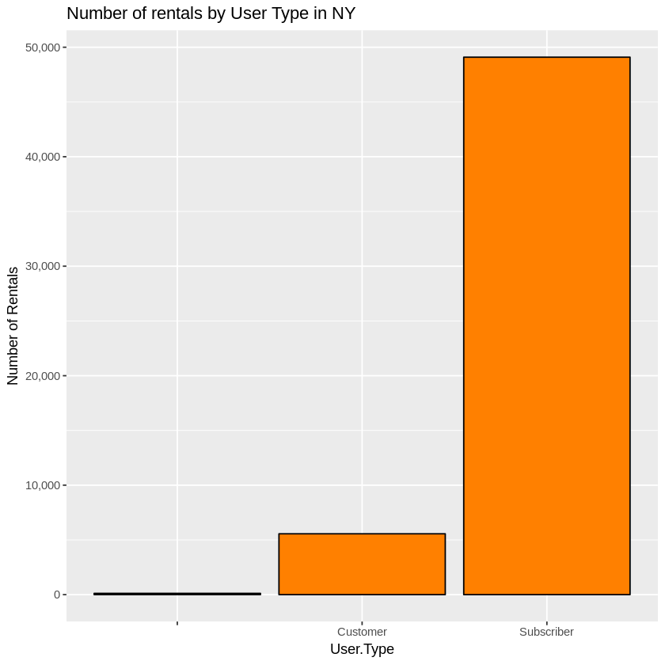

```r
#For Ny
     ggplot(aes(x = User.Type), data = ny) +
            geom_bar(color = 'black', fill = '#FF8000') +
            xlab('User.Type') +
            ylab('Rental Count')+
            ggtitle("Number of rentals by User Type in NY")+
            scale_y_continuous(name="Number of Rentals", labels = comma)

#Numeric confirmation:
table(ny$User.Type)

#Summary
by(ny$User.Type, ny$month, summary)
```

```
             Customer Subscriber
         1      23450      65600
```

```
wash$month: 01
             Customer Subscriber
         0       1136       7810
------------------------------------------------------------
wash$month: 02
             Customer Subscriber
         0       2248       9315
------------------------------------------------------------
wash$month: 03
             Customer Subscriber
         0       2698       9914
------------------------------------------------------------
wash$month: 04
             Customer Subscriber
         0       6304      12218
------------------------------------------------------------
wash$month: 05
             Customer Subscriber
         0       4925      12147
------------------------------------------------------------
wash$month: 06
             Customer Subscriber
         0       6139      14196
```

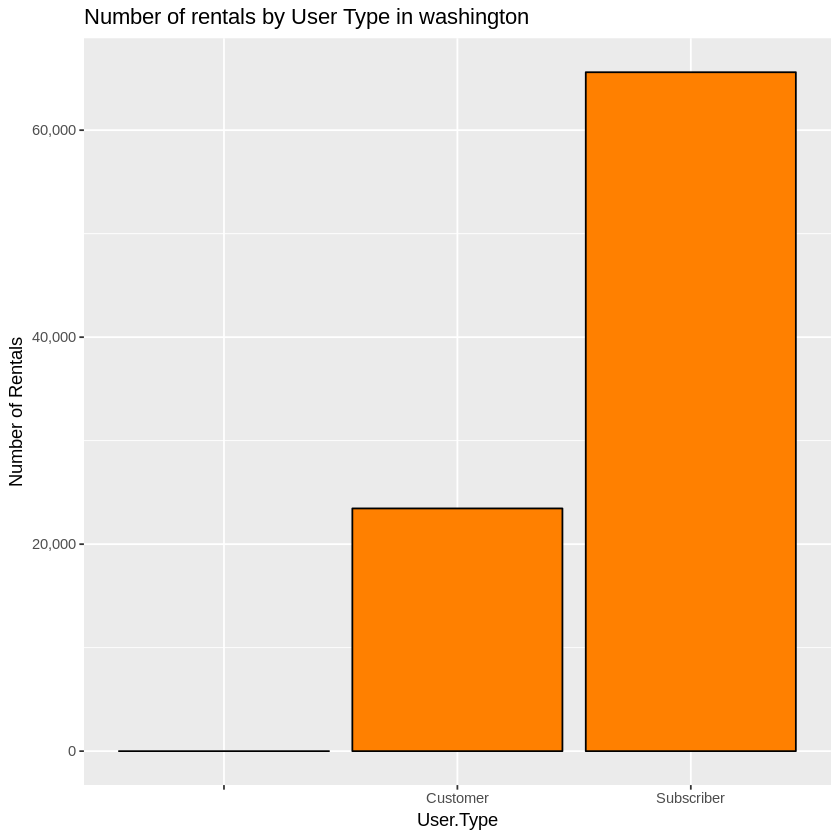

```r
#For Washington:
   ggplot(aes(x = User.Type), data = wash) +
   geom_bar(color = 'black', fill = '#FF8000') +
   xlab('User.Type') +
   ylab('Rental Count')+
   ggtitle("Number of rentals by User Type in washington")+
   scale_y_continuous(name="Number of Rentals", labels = comma)

#Numeric Confirmation:
table(wash$User.Type)

#Summary
by(wash$User.Type, wash$month, summary)
```

```
             Customer Subscriber
         1       1746       6883
```

```
chi$month: 01
             Customer Subscriber
         0         28        622
------------------------------------------------------------
chi$month: 02
             Customer Subscriber
         0        125        805
------------------------------------------------------------
chi$month: 03
             Customer Subscriber
         0         56        747
------------------------------------------------------------
chi$month: 04
             Customer Subscriber
         0        357       1169
------------------------------------------------------------
chi$month: 05
             Customer Subscriber
         0        448       1457
------------------------------------------------------------
chi$month: 06
             Customer Subscriber
         1        732       2083
```

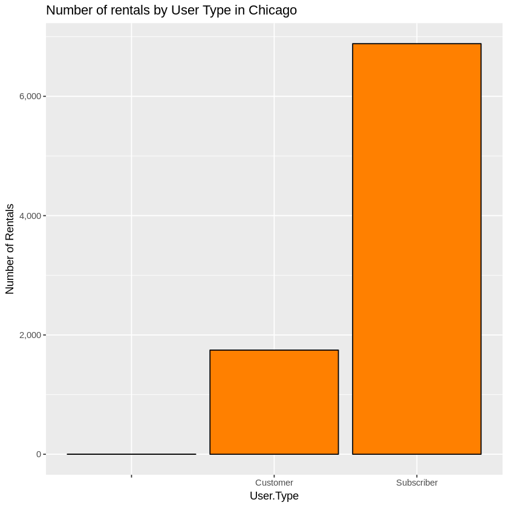

```r
#For Chicago:
   ggplot(aes(x = User.Type), data = chi) +
   geom_bar(color = 'black', fill = '#FF8000') +
   xlab('User.Type') +
   ylab('Rental Count')+
   ggtitle("Number of rentals by User Type in Chicago")+
   scale_y_continuous(name="Number of Rentals", labels = comma)

#Numeric Confirmation
table(chi$User.Type)

#Summary
by(chi$User.Type, chi$month, summary)
```